# Decision Trees

## Description

In this practical we will experiment with Decision Trees using the existing implementation on `scikit-learn`. We will be exploring a *classic* dataset in Machine learning called "Iris Dataset". If you want to know more about the dataset you can find it at the following [link](https://archive.ics.uci.edu/ml/datasets/iris) ([actual data](https://archive.ics.uci.edu/ml/machine-learning-databases/iris/iris.data), [feature names](https://archive.ics.uci.edu/ml/machine-learning-databases/iris/iris.names)).

The aim of this practical is twofold: first, to familiarise yourselves with the `scikit` framework and the many capabilities it has to offer in terms of manipulating data, and applying training algorithms. Second, you will be able to apply the knowledge you acquired regarding features, overfitting/underfitting and...well Decision Trees, obviously!

**SUPER IMPORTANT NOTE**: The documentation is your friend. Find out more about the Decision Trees implementation on scikit-learn [here](http://scikit-learn.org/stable/modules/tree.html#classification) and [here](http://scikit-learn.org/stable/modules/generated/sklearn.tree.DecisionTreeClassifier.html#sklearn.tree.DecisionTreeClassifier).

## Exercise 1 - Dataset Analysis

Let's first do all the necessary imports and load the iris dataset using scikit. Then try to answer/implement the following questions (you don't have to write a report).

**Note**: Refrain from looking at the documentation for iris (yeah I know...) to find the answers, and instead use your numpy expertise on manipulating the arrays `X` and `y`. All you need to know is that `X` contains the examples (rows hold the examples, columns the features), and `y` has the labels for each example. `feature_names`, as the name of the variable implies, is an array with the names of each feature.

**Note 2**: You can also use Pandas as well to answer the following questions simply by importing `X`, `y` and `feature_names`.

1. How many features does the dataset have?
2. How many examples are there in the dataset?
3. How many classes does the dataset have? What are they? (**Hint**: use the method `iris.target_names`)
4. What are the types of the features?
5. Compute the mean and standard deviation of the first two features.

```python
!pip install matplotlib scikit-learn
```

```python
print(__doc__)

import numpy as np
import matplotlib.pyplot as plt

from sklearn.datasets import load_iris
from sklearn.tree import DecisionTreeClassifier
from sklearn import tree

# Load data
iris = load_iris()

X = iris.data
y = iris.target
feature_names = iris.feature_names
```

```
Automatically created module for IPython interactive environment
```

```python
# Answer first 3 questions here
print('Number of features:', X.shape[1])
print('Number of examples: ', len(X))
print('Class names: ', iris.target_names)
print('Number of classes:', len(iris.target_names))


# 4th question. Hint: There are multiple ways to guess the type of features: a) look at the dtype of the numpy array,
# or b) just eyeball some feature values
print('X type', X.dtype)
for i in range(0, len(feature_names)):
    print('Feature \'{}\' has type \'{}\''.format(feature_names[i], X[i].dtype))

print(X[0][:])

#TODO: Implement 5th question.
for i in range(0,2):
    print('Mean: {}, Std: {} of feature {} '.format(np.average(X[:, i]), np.std(X[:, i]), i+1))
```

```
Number of features: 4
Number of examples:  150
Class names:  ['setosa' 'versicolor' 'virginica']
Number of classes: 3
X type float64
Feature 'sepal length (cm)' has type 'float64'
Feature 'sepal width (cm)' has type 'float64'
Feature 'petal length (cm)' has type 'float64'
Feature 'petal width (cm)' has type 'float64'
[5.1 3.5 1.4 0.2]
Mean: 5.843333333333334, Std: 0.8253012917851409 of feature 1
Mean: 3.0573333333333337, Std: 0.4344109677354946 of feature 2
```

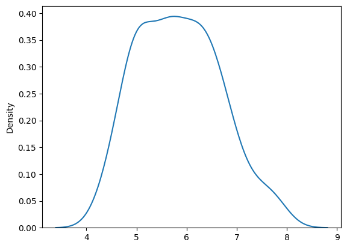

```python
import seaborn as sns
import matplotlib.pyplot as plt

sns.kdeplot(X[:, 0])
plt.show()
```

- What do you think now about the mean we computed earlier? Is it really representative?
- Now it's your turn. Plot histograms for the rest of the features using a for loop. What do you notice?

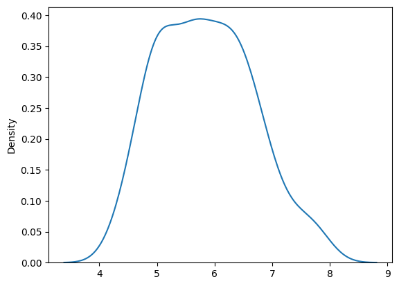

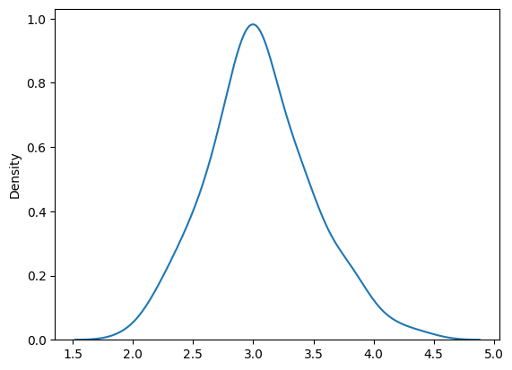

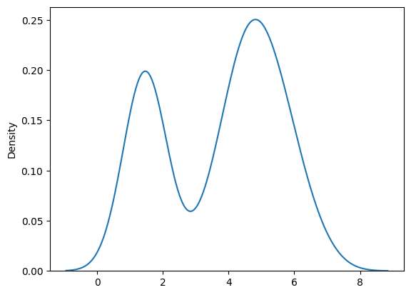

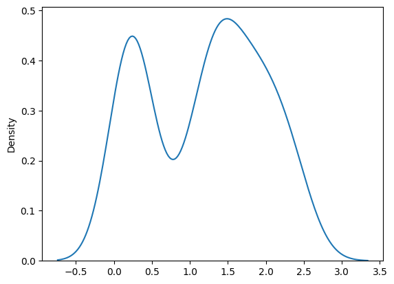

```python
for i in range(0, len(feature_names)):
    sns.kdeplot(X[:, i])
    plt.show()
```

## Excercise 2 - Train Decision Trees

Ok, we know a little bit now how our features look like. Next, let's go ahead and train a Decision Tree. We will be using an implementation that only handles numeric values (luckily iris only has numeric values, otherwise we would have to convert binary and categorical to 1-of-k representations).

We will be using `sklearn.tree.DecisionTreeClassifier` which has many more hyperparameters than we have seen in the Theory part (yes, it's an advanced production-ready code). The two most interesting hyperparamters you need to care about are the `criterion` and the `max_depth`.

For the first one, scikit-learn uses two slightly more sophisticated scoring functions (namely Gini impurity (*default*) and Information Gain (`entropy`)), than the one we have seen in Theory. You can find more information [here](https://en.wikipedia.org/wiki/Decision_tree_learning). Leave it to the default setting (`criterion="gini"`), and you can experiment with it later if you have time.

We mostly care about `max_depth` because we know that this is our key to controlling the complexity of the final decision tree (i.e., how many questions to ask), hence controllling overfitting and underfitting.

Finally, after 3 weeks of waiting, we are ready for some real action! Let's see how we can:

**SUPER IMPORTANT NOTE: Go through each of the lines ONE-by-ONE and try to understand what each step does!!!**

```python
# set max_depth
depth=1
#dt = tree.DecisionTreeClassifier(max_depth=depth)
dt= tree.DecisionTreeClassifier(criterion="entropy", max_depth=3)
# Train on data
dt.fit(X, y)

# predict class on the 10th example
# Notice how we reshape the 10th row of X. This is necessary as predict expects a 1-d array,
# i.e., shape (1,N), rather than a vector.
# NOTE: Try without reshaping and see what will happen.
example_id = 10
pred_10 = dt.predict(X[10].reshape(1,-1))

# get the class name, just for fun!
pred_10_class = iris.target_names[pred_10[0]]

print("Prediction for example {} is {} and has class name: {}".format(example_id, pred_10, pred_10_class))
# Predict on the whole training set
preds = dt.predict(X)
# A very fancy way to compute training accuracy! (It can't get any more `Pythonic` that this :D )
# NOTE: What is `preds == y` really? Try to print it and check its shape...
train_acc = np.mean(preds == y)
print("Training accuracy: {:1.3f} for depth = {}".format(train_acc, depth))

# dt.predict(X[10])
print(X[10].shape)
print(X[10].reshape(1, -1).shape)

a = np.ones((3,4))
print(a.shape)
print(a.reshape(1, -1).shape)
```

[output not shown]

Now it's your turn!

- Was the prediction of the 10th example correct? *Hint*: Check against the gold labels in `y`.
- Train a decision tree with max_depth=2.
- What is the training accuracy?
- Compare this training accuracy with the previous one.
- Repeat the same steps for max_depth=10. What do you notice?

```python
# get correct class for 10th example
print('Correct class for 10th example = ', y[10])

# compute for depths=2 and 10.  We are kinda overfitting, no? ;)
depth = 2
dt = tree.DecisionTreeClassifier(max_depth=depth)
# Train on data
dt.fit(X, y)
preds = dt.predict(X)
train_acc = np.mean(preds == y)
print("Training accuracy: {} for depth = {}".format(train_acc, depth))

depth = 10
dt = tree.DecisionTreeClassifier(max_depth=depth)
# Train on data
dt.fit(X, y)
preds = dt.predict(X)
train_acc = np.mean(preds == y)
print("Training accuracy: {} for depth = {}".format(train_acc, depth))
```

```
Correct class for 10th example =  0
Training accuracy: 0.96 for depth = 2
Training accuracy: 1.0 for depth = 10
```

## Exercise 3 - Plot Decision Trees

Let's try now to see what the actual Decision Tree looks like!

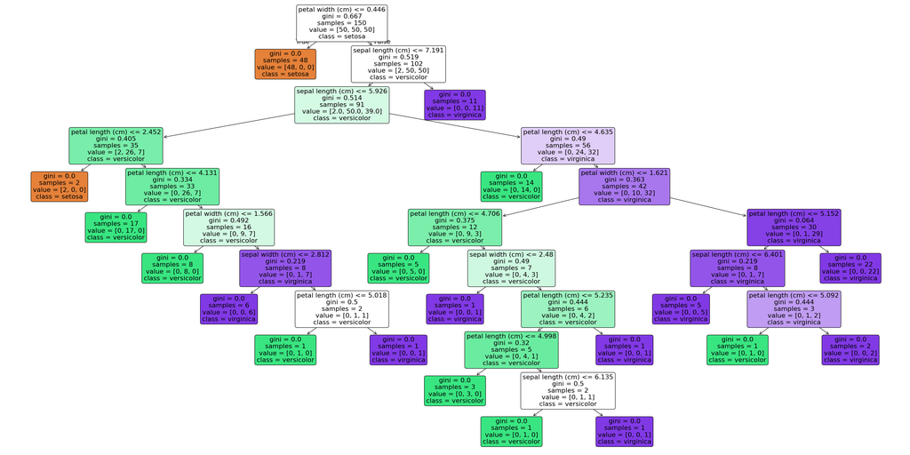

```python
depth=10
#crt='entropy'
crt='gini'
dt = tree.DecisionTreeClassifier(criterion=crt, splitter='random', max_depth=depth)
# Train on data
dt.fit(X, y)
plt.figure(figsize=(40,20))
_ = tree.plot_tree(dt, feature_names=iris.feature_names, class_names=iris.target_names, filled=True, rounded=True)
plt.show()
```

Your turn! Try with depths 2 and 10.

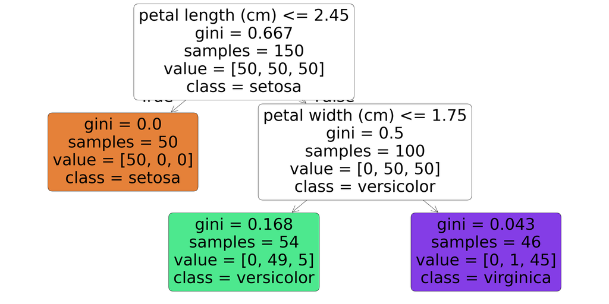

```python
depth=2
dt = tree.DecisionTreeClassifier(max_depth=depth)
# Train on data
dt.fit(X, y)
plt.figure(figsize=(40,20))
_ = tree.plot_tree(dt, feature_names=iris.feature_names, class_names=iris.target_names, filled=True, rounded=True)
plt.show()
```

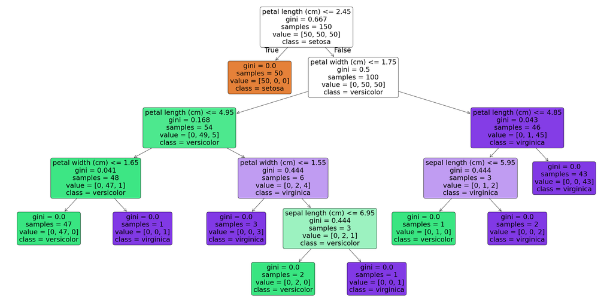

```python
depth=10
dt = tree.DecisionTreeClassifier(max_depth=depth)
# Train on data
dt.fit(X, y)
plt.figure(figsize=(40,20))
_ = tree.plot_tree(dt, feature_names=iris.feature_names, class_names=iris.target_names, filled=True, rounded=True)
plt.show()
```

## Exercise 4 - Decision Boundaries

This is optional, but very interesting. We will compute the decision boundaries (and the surfaces of the corresponding classes they separate into) for a trained model in 2D for all pairs of features. Here is how:

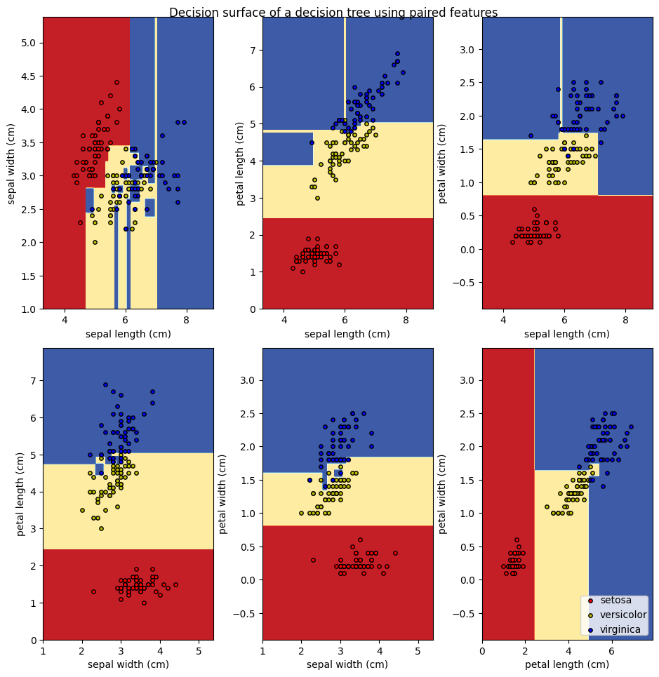

```python
depth = 1

# Parameters
n_classes = 3
plot_colors = "ryb"
plot_step = 0.02
plt.figure(figsize=(10,10))

for pairidx, pair in enumerate([[0, 1], [0, 2], [0, 3],
                                [1, 2], [1, 3], [2, 3]]):
    # We only take the two corresponding features
    X = iris.data[:, pair]
    y = iris.target

    # Train
    dt = DecisionTreeClassifier().fit(X, y)

    # Plot the decision boundary
    plt.subplot(2, 3, pairidx + 1)

    x_min, x_max = X[:, 0].min() - 1, X[:, 0].max() + 1
    y_min, y_max = X[:, 1].min() - 1, X[:, 1].max() + 1
    xx, yy = np.meshgrid(np.arange(x_min, x_max, plot_step),
                         np.arange(y_min, y_max, plot_step))
    plt.tight_layout(h_pad=0.5, w_pad=0.5, pad=2.5)

    Z = dt.predict(np.c_[xx.ravel(), yy.ravel()])
    Z = Z.reshape(xx.shape)
    cs = plt.contourf(xx, yy, Z, cmap=plt.cm.RdYlBu)

    plt.xlabel(iris.feature_names[pair[0]])
    plt.ylabel(iris.feature_names[pair[1]])

    # Plot the training points
    for i, color in zip(range(n_classes), plot_colors):
        idx = np.where(y == i)
        plt.scatter(X[idx, 0], X[idx, 1], c=color, label=iris.target_names[i],
                    cmap=plt.cm.RdYlBu, edgecolor='black', s=15)

plt.suptitle("Decision surface of a decision tree using paired features")
plt.legend(loc='lower right', borderpad=0, handletextpad=0)
plt.axis("tight")
plt.show()
```

You can play with different depths and see how much (if any; remember this is a very small dataset) the boundaries change.